# p8105_hw3_pl2811

Pei Hsin Lin

10/18/2021

```r
library(tidyverse)
```

```r
library(dplyr)
library(ggridges)
library(ggplot2)
library(forcats)
library(p8105.datasets)
library(httr)
library(jsonlite)
library(viridis)
library(patchwork)
library(knitr)
library(png)
```

###How many aisles are there, and which aisles are the most items ordered from?

```r
data("instacart")
skimr::skim(aisle_count)
```

```r
aisle_count<-instacart %>%
    group_by(aisle) %>%
    count()
```

#There are 134 aisles

```r
 aisle_order= order(aisle_count$n, decreasing=T)
 aisle_sorted = aisle_count[aisle_order,]
 head(aisle_sorted, 1)
```

```
## # A tibble: 1 × 2
## # Groups:   aisle [1]
##   aisle                 n
##   <chr>             <int>
## 1 fresh vegetables 150609
```

# most items ordered from fresh vegetables

### Make a plot that shows the number of items ordered in each aisle, limiting this to aisles with more than 10000 items ordered. Arrange aisles sensibly, and organize your plot so others can read it.

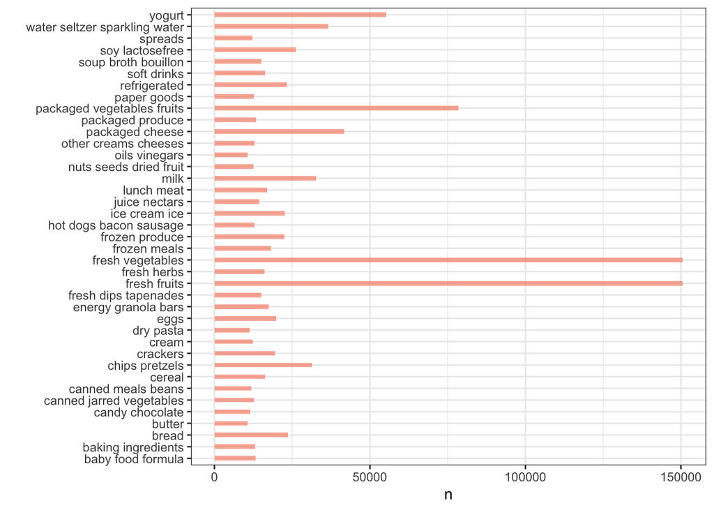

```r
instacart_order<-filter(aisle_sorted, n > 10000)
instacart_order %>%
mutate(name = fct_reorder(aisle, desc(n))) %>%
ggplot( aes(x=aisle, y=n)) +
geom_bar(stat="identity", fill="#f68060", alpha=.6, width=.4) +
coord_flip() +
xlab("") +
theme_bw()
```

```r
popular_items<-select(instacart, aisle, product_name)

popular_items<-filter(popular_items, aisle %in% c("dog food care", "baking ingredients",
                                                  "packaged vegetables fruits" ))

popular_items_tables<-popular_items %>%
    group_by(product_name, aisle) %>%
    count()

aisle_popular<-popular_items_tables %>%
    group_by(aisle) %>%
    top_n(1, n)

aisle_popular
```

```
## # A tibble: 3 × 3
## # Groups:   aisle [3]
##   product_name                                  aisle                          n
##   <chr>                                         <chr>                      <int>
## 1 Light Brown Sugar                             baking ingredients           499
## 2 Organic Baby Spinach                          packaged vegetables fruits  9784
## 3 Snack Sticks Chicken & Rice Recipe Dog Treats dog food care                 30
```

### Make a table showing the mean hour of the day at which Pink Lady Apples and Coffee Ice Cream are ordered on each day of the week;

# format this table for human readers (i.e. produce a 2 x 7 table)

```r
week<-filter(instacart, product_name %in% c("Pink Lady Apples", "Coffee Ice Cream"))
week<-select(week, order_dow, order_hour_of_day, product_name )
week<- week %>%
  group_by(order_dow, product_name ) %>%
  summarise_at(vars(order_hour_of_day), list(mean= mean))

week<-pivot_wider(
 week,
  names_from = "product_name",
  values_from = "mean")

 week= subset(week, select = -c( order_dow ))
week
```

```
## # A tibble: 7 × 2
##   `Coffee Ice Cream` `Pink Lady Apples`
##                <dbl>              <dbl>
## 1               13.8               13.4
## 2               14.3               11.4
## 3               15.4               11.7
## 4               15.3               14.2
## 5               15.2               11.6
## 6               12.3               12.8
## 7               13.8               11.9
```

```r
library(p8105.datasets)
data("brfss_smart2010")
brfss_smart2010=brfss_smart2010%>%
  janitor::clean_names()

overall_health<-filter(brfss_smart2010,topic %in% c("Overall Health"))
overall_health<-filter(brfss_smart2010, response %in% c("Poor","Fair","Good","Very good", "Excellent"))
topic<-overall_health %>%
    group_by(response) %>%
    count()


target <- c("Poor","Fair","Good","Very good", "Excellent")
overall_health<-overall_health[order(factor(overall_health$response, levels = target)),]
```

#In 2002, which states were observed at 7 or more locations? What about in 2010?

```r
overall_health_2002<-filter(overall_health, year %in% c("2002"))
location<- overall_health_2002 %>%
  group_by(locationabbr)%>%
    count()

location02_over_7<-filter(location, n>=7)
view(location02_over_7)
knitr::kable(location02_over_7, "pipe")
```

| locationabbr | n |
| --- | --- |
| AZ | 10 |
| CO | 20 |
| CT | 35 |
| DE | 15 |
| FL | 35 |
| GA | 15 |
| HI | 20 |
| ID | 10 |
| IL | 15 |
| IN | 10 |
| KS | 15 |
| LA | 15 |
| MA | 40 |
| MD | 30 |
| ME | 10 |
| MI | 20 |
| MN | 20 |
| MO | 10 |
| NC | 35 |
| NE | 15 |
| NH | 25 |
| NJ | 40 |
| NV | 10 |
| NY | 25 |
| OH | 20 |
| OK | 15 |
| OR | 15 |
| PA | 50 |
| RI | 20 |
| SC | 15 |
| SD | 10 |
| TN | 10 |
| TX | 10 |
| UT | 25 |
| VT | 15 |
| WA | 20 |

```r
overall_health_2010<-filter(overall_health, year %in% c("2010"))
location<- overall_health_2010 %>%
  group_by(locationabbr)%>%
    count()

location10_over_7<-filter(location, n>=7)
knitr::kable(location10_over_7, "pipe")
```

| locationabbr | n |
| --- | --- |
| AL | 15 |
| AR | 15 |
| AZ | 15 |
| CA | 60 |
| CO | 35 |
| CT | 25 |
| DE | 15 |
| FL | 205 |
| GA | 20 |
| HI | 20 |
| IA | 10 |
| ID | 30 |
| IL | 10 |
| IN | 15 |
| KS | 20 |
| LA | 25 |
| MA | 45 |
| MD | 60 |
| ME | 30 |
| MI | 20 |
| MN | 25 |
| MO | 15 |
| MS | 10 |
| MT | 15 |
| NC | 60 |
| ND | 15 |
| NE | 50 |
| NH | 25 |
| NJ | 95 |
| NM | 30 |
| NV | 10 |
| NY | 45 |
| OH | 40 |
| OK | 15 |
| OR | 20 |
| PA | 35 |
| RI | 25 |
| SC | 35 |
| SD | 10 |
| TN | 25 |
| TX | 80 |
| UT | 30 |
| VT | 30 |
| WA | 50 |
| WY | 10 |

# Table location02_over_7 shows the 36 states were observed at 7 or more locations in 2002.